# Final Project - Popular Spotify Songs

Johnny Arguedas & Mark Hageman

11/18/2020

**Mid-term review for this project provided by Eunsun Yook**

### Section 1: Introduction

Streaming music services have been able to collect a wealth of data for song characteristics, amount of streams, and user interaction. Spotify has taken this data to create playlists curated to a user’s taste based on their listening habits. Considering how songs have been quantified by Spotify, is it possible to find correlations for a song’s popularity based on the other quantifiable fields Spotify makes available?

With the [Spotify](https://www.spotify.com/us/) dataset retrieved with the `spotifyr` package, we will look at 12 variables from almost 33,000 songs and see how they interact with each other, and whether they are significant in determining popularity. As genres of music can have very different characteristics, it may make more sense to gauge popularity based on each genre’s representative statistics rather than overall.

We will first compare variables to determine which have influence on the popularity of a song. We will then apply a multiple linear regression to the data to make a prediction as to what characteristics are likely, within each genre, to produce a popular song.

A predictive model of popularity can help songwriters craft a song based on data-driven methods. Users will also benefit by being able to discover songs based on their preferred characteristics, and see whether they prefer more or less popular songs.

### Section 2: Required Packages

```r
library(tidyverse)
library(scales)
library(table1)
library(htmltools)
library(cowplot)
library(rlang)
library(Hmisc)
library(gridExtra)
library(ggcorrplot)
```

This analysis will make use of the following packages:

- [tidyverse](https://www.tidyverse.org/) - A collection of various packages designed to make it easier to make data tidy for analysis
- [scales](https://www.rdocumentation.org/packages/scales/versions/0.4.1) - A package with various string formatting functions
- [table1](https://cran.r-project.org/web/packages/table1/vignettes/table1-examples.html) - A package for the creation of HTML tables of descriptive statistics
- [htmltools](https://cran.r-project.org/web/packages/htmltools/index.html) - A package to enable the inclusion of external HTML files
- [cowplot](https://cran.r-project.org/web/packages/cowplot/vignettes/introduction.html) - A package that enhances ggplot by adding themes
- [rlang](https://cran.r-project.org/web/packages/rlang/index.html) - A package that provides tools to work with core features of R and `tidyverse`
- [Hmisc](https://cran.r-project.org/web/packages/Hmisc/index.html) - A package that contains many functions useful for data analysis, high-level graphics, utility operations, and more
- [gridExtra](https://cran.r-project.org/web/packages/gridExtra/index.html) - A package to help work with “grid” graphics
- [ggcorrplot](https://cran.r-project.org/web/packages/ggcorrplot/) - A package to produce a visualized correlation matrix using `ggplot2`

### Section 3: Data Preparation

```r
songs <- read.csv('spotify_songs.csv', stringsAsFactors = FALSE)
```

The data used in this analysis is available as part of the [tidytuesdayR](https://github.com/rfordatascience/tidytuesday/blob/master/data/2020/2020-01-21/readme.md) package, and is also available for download here.

The codebook is also available on the [tidytuesday](https://github.com/rfordatascience/tidytuesday/blob/master/data/2020/2020-01-21/readme.md) GitHub page.

The data set, which was originally created on 2020-01-21, consists of 32,833 records, each with 23 columns. Each record represents a single song, and the columns represent various aspects of each song:

```r
htmltools::includeHTML("codebook.html")
```

| variable | class | description |
| --- | --- | --- |
| track_id | character | Song unique ID |
| track_name | character | Song Name |
| track_artist | character | Song Artist |
| track_popularity | double | Song Popularity (0-100) where higher is better |
| track_album_id | character | Album unique ID |
| track_album_name | character | Song album name |
| track_album_release_date | character | Date when album released |
| playlist_name | character | Name of playlist |
| playlist_id | character | Playlist ID |
| playlist_genre | character | Playlist genre |
| playlist_subgenre | character | Playlist subgenre |
| danceability | double | Danceability describes how suitable a track is for dancing based on a combination of musical elements including tempo, rhythm stability, beat strength, and overall regularity. A value of 0.0 is least … |
| energy | double | Energy is a measure from 0.0 to 1.0 and represents a perceptual measure of intensity and activity. Typically, energetic tracks feel fast, loud, and noisy. For example, death metal has high energy, whi… |
| key | double | The estimated overall key of the track. Integers map to pitches using standard Pitch Class notation . E.g. 0 = C, 1 = C♯/D♭, 2 = D, and so on. If no key was detected, the value is -1. |
| loudness | double | The overall loudness of a track in decibels (dB). Loudness values are averaged across the entire track and are useful for comparing relative loudness of tracks. Loudness is the quality of a sound that… |
| mode | double | Mode indicates the modality (major or minor) of a track, the type of scale from which its melodic content is derived. Major is represented by 1 and minor is 0. |
| speechiness | double | Speechiness detects the presence of spoken words in a track. The more exclusively speech-like the recording (e.g. talk show, audio book, poetry), the closer to 1.0 the attribute value. Values above 0.… |
| acousticness | double | A confidence measure from 0.0 to 1.0 of whether the track is acoustic. 1.0 represents high confidence the track is acoustic. |
| instrumentalness | double | Predicts whether a track contains no vocals. “Ooh” and “aah” sounds are treated as instrumental in this context. Rap or spoken word tracks are clearly “vocal”. The closer the instrumentalness value is… |
| liveness | double | Detects the presence of an audience in the recording. Higher liveness values represent an increased probability that the track was performed live. A value above 0.8 provides strong likelihood that the… |
| valence | double | A measure from 0.0 to 1.0 describing the musical positiveness conveyed by a track. Tracks with high valence sound more positive (e.g. happy, cheerful, euphoric), while tracks with low valence sound mo… |
| tempo | double | The overall estimated tempo of a track in beats per minute (BPM). In musical terminology, tempo is the speed or pace of a given piece and derives directly from the average beat duration. |
| duration_ms | double | Duration of song in milliseconds |

Because the columns are named sensibly, we won’t need to re-name any of them.

In examining the structure of the data set, we can see that `track_album_release_date` should be re-formatted as a date, and that `playlist_genre` and `playlist_subgenre` should be made into factors.

```r
str(songs)
```

```
## 'data.frame':    32833 obs. of  23 variables:
##  $ track_id                : chr  "6f807x0ima9a1j3VPbc7VN" "0r7CVbZTWZgbTCYdfa2P31" "1z1Hg7Vb0AhHDiEmnDE79l" "75FpbthrwQmzHlBJLuGdC7" ...
##  $ track_name              : chr  "I Don't Care (with Justin Bieber) - Loud Luxury Remix" "Memories - Dillon Francis Remix" "All the Time - Don Diablo Remix" "Call You Mine - Keanu Silva Remix" ...
##  $ track_artist            : chr  "Ed Sheeran" "Maroon 5" "Zara Larsson" "The Chainsmokers" ...
##  $ track_popularity        : int  66 67 70 60 69 67 62 69 68 67 ...
##  $ track_album_id          : chr  "2oCs0DGTsRO98Gh5ZSl2Cx" "63rPSO264uRjW1X5E6cWv6" "1HoSmj2eLcsrR0vE9gThr4" "1nqYsOef1yKKuGOVchbsk6" ...
##  $ track_album_name        : chr  "I Don't Care (with Justin Bieber) [Loud Luxury Remix]" "Memories (Dillon Francis Remix)" "All the Time (Don Diablo Remix)" "Call You Mine - The Remixes" ...
##  $ track_album_release_date: chr  "2019-06-14" "2019-12-13" "2019-07-05" "2019-07-19" ...
##  $ playlist_name           : chr  "Pop Remix" "Pop Remix" "Pop Remix" "Pop Remix" ...
##  $ playlist_id             : chr  "37i9dQZF1DXcZDD7cfEKhW" "37i9dQZF1DXcZDD7cfEKhW" "37i9dQZF1DXcZDD7cfEKhW" "37i9dQZF1DXcZDD7cfEKhW" ...
##  $ playlist_genre          : chr  "pop" "pop" "pop" "pop" ...
##  $ playlist_subgenre       : chr  "dance pop" "dance pop" "dance pop" "dance pop" ...
##  $ danceability            : num  0.748 0.726 0.675 0.718 0.65 0.675 0.449 0.542 0.594 0.642 ...
##  $ energy                  : num  0.916 0.815 0.931 0.93 0.833 0.919 0.856 0.903 0.935 0.818 ...
##  $ key                     : int  6 11 1 7 1 8 5 4 8 2 ...
##  $ loudness                : num  -2.63 -4.97 -3.43 -3.78 -4.67 ...
##  $ mode                    : int  1 1 0 1 1 1 0 0 1 1 ...
##  $ speechiness             : num  0.0583 0.0373 0.0742 0.102 0.0359 0.127 0.0623 0.0434 0.0565 0.032 ...
##  $ acousticness            : num  0.102 0.0724 0.0794 0.0287 0.0803 0.0799 0.187 0.0335 0.0249 0.0567 ...
##  $ instrumentalness        : num  0.00 4.21e-03 2.33e-05 9.43e-06 0.00 0.00 0.00 4.83e-06 3.97e-06 0.00 ...
##  $ liveness                : num  0.0653 0.357 0.11 0.204 0.0833 0.143 0.176 0.111 0.637 0.0919 ...
##  $ valence                 : num  0.518 0.693 0.613 0.277 0.725 0.585 0.152 0.367 0.366 0.59 ...
##  $ tempo                   : num  122 100 124 122 124 ...
##  $ duration_ms             : int  194754 162600 176616 169093 189052 163049 187675 207619 193187 253040 ...
```

```r
songs$track_album_release_date <- as.Date(songs$track_album_release_date)
songs$playlist_genre <- as.factor(songs$playlist_genre)
songs$playlist_subgenre <- as.factor(songs$playlist_subgenre)
```

Is there any missing data?

```r
nrow(songs[complete.cases(songs), ])
```

```
## [1] 30942
```

```r
colSums(is.na(songs))
```

```
##                 track_id               track_name             track_artist
##                        0                        5                        5
##         track_popularity           track_album_id         track_album_name
##                        0                        0                        5
## track_album_release_date            playlist_name              playlist_id
##                     1886                        0                        0
##           playlist_genre        playlist_subgenre             danceability
##                        0                        0                        0
##                   energy                      key                 loudness
##                        0                        0                        0
##                     mode              speechiness             acousticness
##                        0                        0                        0
##         instrumentalness                 liveness                  valence
##                        0                        0                        0
##                    tempo              duration_ms
##                        0                        0
```

The NA values in this data set exist in the `track_name`, `track_artist`, `track_album_name`, and `track_album_release_date`. Given the nature of the columns with missing values, it does not make sense for us to make any imputations.

How many rows still have missing data?

```r
na_rows <- nrow(songs) - nrow(songs[complete.cases(songs), ])
pct_na_rows <- na_rows / nrow(songs)
```

Only 1891 rows are still missing data at this point. This is only about 6% of the total number of rows, so we’ll just drop those rows from the data set.

```r
songs <- na.omit(songs)
```

Next we’ll look at summaries of each of the numeric values to be sure they make sense, and check for any outliers.

```r
summary(songs)
```

```
##    track_id          track_name        track_artist       track_popularity
##  Length:30942       Length:30942       Length:30942       Min.   :  0.00
##  Class :character   Class :character   Class :character   1st Qu.: 25.00
##  Mode  :character   Mode  :character   Mode  :character   Median : 45.00
##                                                           Mean   : 42.76
##                                                           3rd Qu.: 62.00
##                                                           Max.   :100.00
##
##  track_album_id     track_album_name   track_album_release_date
##  Length:30942       Length:30942       Min.   :1957-01-01
##  Class :character   Class :character   1st Qu.:2010-12-03
##  Mode  :character   Mode  :character   Median :2017-01-27
##                                        Mean   :2012-09-09
##                                        3rd Qu.:2019-05-16
##                                        Max.   :2020-01-29
##
##  playlist_name      playlist_id        playlist_genre
##  Length:30942       Length:30942       edm  :5969
##  Class :character   Class :character   latin:4961
##  Mode  :character   Mode  :character   pop  :5303
##                                        r&b  :5094
##                                        rap  :5468
##                                        rock :4147
##
##                  playlist_subgenre  danceability        energy
##  progressive electro house: 1760   Min.   :0.0000   Min.   :0.000175
##  indie poptimism          : 1647   1st Qu.:0.5660   1st Qu.:0.582000
##  latin hip hop            : 1572   Median :0.6740   Median :0.721000
##  neo soul                 : 1547   Mean   :0.6573   Mean   :0.698857
##  southern hip hop         : 1512   3rd Qu.:0.7620   3rd Qu.:0.840000
##  pop edm                  : 1507   Max.   :0.9830   Max.   :1.000000
##  (Other)                  :21397
##       key            loudness            mode        speechiness
##  Min.   : 0.000   Min.   :-46.448   Min.   :0.000   Min.   :0.0000
##  1st Qu.: 2.000   1st Qu.: -8.073   1st Qu.:0.000   1st Qu.:0.0415
##  Median : 6.000   Median : -6.093   Median :1.000   Median :0.0636
##  Mean   : 5.368   Mean   : -6.639   Mean   :0.561   Mean   :0.1082
##  3rd Qu.: 9.000   3rd Qu.: -4.605   3rd Qu.:1.000   3rd Qu.:0.1340
##  Max.   :11.000   Max.   :  1.275   Max.   :1.000   Max.   :0.9180
##
##   acousticness    instrumentalness       liveness         valence
##  Min.   :0.0000   Min.   :0.0000000   Min.   :0.0000   Min.   :0.000
##  1st Qu.:0.0152   1st Qu.:0.0000000   1st Qu.:0.0931   1st Qu.:0.326
##  Median :0.0810   Median :0.0000153   Median :0.1270   Median :0.506
##  Mean   :0.1760   Mean   :0.0869559   Mean   :0.1900   Mean   :0.505
##  3rd Qu.:0.2560   3rd Qu.:0.0050600   3rd Qu.:0.2470   3rd Qu.:0.687
##  Max.   :0.9940   Max.   :0.9940000   Max.   :0.9960   Max.   :0.991
##
##      tempo         duration_ms
##  Min.   :  0.00   Min.   :  4000
##  1st Qu.: 99.97   1st Qu.:186750
##  Median :122.00   Median :214400
##  Mean   :120.94   Mean   :223947
##  3rd Qu.:133.52   3rd Qu.:251100
##  Max.   :239.44   Max.   :517810
##
```

```r
songs %>%
  summarise_if(is.numeric, mean)
```

```
##   track_popularity danceability    energy      key  loudness      mode
## 1         42.75609    0.6572603 0.6988573 5.368011 -6.639354 0.5609528
##   speechiness acousticness instrumentalness  liveness   valence    tempo
## 1   0.1082296    0.1759632       0.08695591 0.1899777 0.5050244 120.9423
##   duration_ms
## 1    223946.6
```

There do not appear to be any outliers among the numeric variables, and all values are within the stated ranges (i.e., values such as `danceability` and `energy` are measured on a scale of 0.0 - 1.0). `mode` is binary variable with 0 and 1 as the only possible values. The longest song has a duration of 517810, which is about 8.63 minutes, which seems entirely reasonable.

Finally, there are several columns we won’t need for our analysis, so we’ll drop them here:

```r
unused_cols <- c('track_id', 'track_album_id', 'track_album_name',
                 'playlist_name', 'playlist_id', 'playlist_subgenre')
songs <- songs[ , -which(names(songs) %in% c(unused_cols))]
```

The data is now clean, with 30942 observations of 17 variables. Here’s what it looks like:

```r
dim(songs)
```

```
## [1] 30942    17
```

```r
head(songs)
```

```
##                                              track_name     track_artist
## 1 I Don't Care (with Justin Bieber) - Loud Luxury Remix       Ed Sheeran
## 2                       Memories - Dillon Francis Remix         Maroon 5
## 3                       All the Time - Don Diablo Remix     Zara Larsson
## 4                     Call You Mine - Keanu Silva Remix The Chainsmokers
## 5               Someone You Loved - Future Humans Remix    Lewis Capaldi
## 6     Beautiful People (feat. Khalid) - Jack Wins Remix       Ed Sheeran
##   track_popularity track_album_release_date playlist_genre danceability energy
## 1               66               2019-06-14            pop        0.748  0.916
## 2               67               2019-12-13            pop        0.726  0.815
## 3               70               2019-07-05            pop        0.675  0.931
## 4               60               2019-07-19            pop        0.718  0.930
## 5               69               2019-03-05            pop        0.650  0.833
## 6               67               2019-07-11            pop        0.675  0.919
##   key loudness mode speechiness acousticness instrumentalness liveness valence
## 1   6   -2.634    1      0.0583       0.1020         0.00e+00   0.0653   0.518
## 2  11   -4.969    1      0.0373       0.0724         4.21e-03   0.3570   0.693
## 3   1   -3.432    0      0.0742       0.0794         2.33e-05   0.1100   0.613
## 4   7   -3.778    1      0.1020       0.0287         9.43e-06   0.2040   0.277
## 5   1   -4.672    1      0.0359       0.0803         0.00e+00   0.0833   0.725
## 6   8   -5.385    1      0.1270       0.0799         0.00e+00   0.1430   0.585
##     tempo duration_ms
## 1 122.036      194754
## 2  99.972      162600
## 3 124.008      176616
## 4 121.956      169093
## 5 123.976      189052
## 6 124.982      163049
```

The variables we are concerned with are `track_album_release_date`, `track_artist`, and `playlist_genre`, and the quantifying variables `track_popularity`, `danceability`, `energy`, `key`, `loudness`, `mode`, `speechiness`, `acousticness`, `instrumentalness`, `liveness`, and `valence`.

- **track_artist**: There are 10,316 distinct artists in this data set.
- **playlist_genre**: Each song is classified by one of 6 distinct genres.

### Section 4: Proposed Exploratory Data Analysis

What is the makeup of songs in our data set, in terms of genre?

Here are summaries of the numeric columns of interest, broken down by playlist_genre:

```r
table1::table1(~ track_popularity + danceability + energy + key + loudness + mode + speechiness + acousticness + instrumentalness +liveness + valence | playlist_genre, data = songs)
```

|  | edm (N=5969) | latin (N=4961) | pop (N=5303) | r&b (N=5094) | rap (N=5468) | rock (N=4147) | Overall (N=30942) |
| --- | --- | --- | --- | --- | --- | --- | --- |
| track_popularity |  |  |  |  |  |  |  |
| Mean (SD) | 34.9 (23.1) | 47.6 (25.3) | 48.1 (25.0) | 41.8 (26.0) | 43.6 (23.3) | 41.4 (24.7) | 42.8 (25.0) |
| Median [Min, Max] | 36.0 [0, 99.0] | 51.0 [0, 100] | 52.0 [0, 100] | 45.0 [0, 99.0] | 48.0 [0, 98.0] | 45.0 [0, 95.0] | 45.0 [0, 100] |
| danceability |  |  |  |  |  |  |  |
| Mean (SD) | 0.655 (0.123) | 0.713 (0.114) | 0.641 (0.128) | 0.670 (0.139) | 0.718 (0.137) | 0.520 (0.141) | 0.657 (0.144) |
| Median [Min, Max] | 0.658 [0.162, 0.983] | 0.729 [0.0771, 0.979] | 0.653 [0.0985, 0.979] | 0.689 [0.140, 0.977] | 0.737 [0.150, 0.975] | 0.523 [0, 0.956] | 0.674 [0, 0.983] |
| energy |  |  |  |  |  |  |  |
| Mean (SD) | 0.803 (0.139) | 0.708 (0.152) | 0.698 (0.171) | 0.589 (0.179) | 0.650 (0.171) | 0.739 (0.194) | 0.699 (0.181) |
| Median [Min, Max] | 0.831 [0.106, 0.998] | 0.728 [0.000175, 1.00] | 0.724 [0.00814, 0.999] | 0.594 [0.0118, 0.995] | 0.665 [0.0161, 0.999] | 0.785 [0.0167, 0.998] | 0.721 [0.000175, 1.00] |
| key |  |  |  |  |  |  |  |
| Mean (SD) | 5.35 (3.56) | 5.48 (3.64) | 5.30 (3.63) | 5.39 (3.59) | 5.45 (3.71) | 5.20 (3.54) | 5.37 (3.61) |
| Median [Min, Max] | 6.00 [0, 11.0] | 6.00 [0, 11.0] | 5.00 [0, 11.0] | 6.00 [0, 11.0] | 6.00 [0, 11.0] | 5.00 [0, 11.0] | 6.00 [0, 11.0] |
| loudness |  |  |  |  |  |  |  |
| Mean (SD) | -5.41 (2.35) | -6.22 (2.85) | -6.30 (2.61) | -7.81 (2.86) | -7.01 (3.05) | -7.41 (3.35) | -6.64 (2.95) |
| Median [Min, Max] | -4.95 [-19.6, 1.14] | -5.73 [-46.4, -0.0460] | -5.83 [-26.3, -0.700] | -7.38 [-34.3, -0.478] | -6.48 [-26.2, 0.642] | -6.82 [-26.1, 1.28] | -6.09 [-46.4, 1.28] |
| mode |  |  |  |  |  |  |  |
| Mean (SD) | 0.519 (0.500) | 0.562 (0.496) | 0.586 (0.493) | 0.519 (0.500) | 0.519 (0.500) | 0.696 (0.460) | 0.561 (0.496) |
| Median [Min, Max] | 1.00 [0, 1.00] | 1.00 [0, 1.00] | 1.00 [0, 1.00] | 1.00 [0, 1.00] | 1.00 [0, 1.00] | 1.00 [0, 1.00] | 1.00 [0, 1.00] |
| speechiness |  |  |  |  |  |  |  |
| Mean (SD) | 0.0869 (0.0713) | 0.103 (0.0881) | 0.0748 (0.0686) | 0.119 (0.108) | 0.196 (0.133) | 0.0587 (0.0464) | 0.108 (0.102) |
| Median [Min, Max] | 0.0602 [0.0239, 0.624] | 0.0681 [0.0232, 0.662] | 0.0495 [0.0228, 0.869] | 0.0692 [0.0224, 0.918] | 0.174 [0.0243, 0.877] | 0.0427 [0, 0.488] | 0.0636 [0, 0.918] |
| acousticness |  |  |  |  |  |  |  |
| Mean (SD) | 0.0817 (0.146) | 0.211 (0.214) | 0.173 (0.220) | 0.263 (0.256) | 0.196 (0.221) | 0.140 (0.208) | 0.176 (0.220) |
| Median [Min, Max] | 0.0193 [0.00000251, 0.985] | 0.139 [0.0000356, 0.989] | 0.0791 [0.00000243, 0.992] | 0.170 [0.0000251, 0.989] | 0.112 [0.00000166, 0.994] | 0.0327 [0, 0.986] | 0.0810 [0, 0.994] |
| instrumentalness |  |  |  |  |  |  |  |
| Mean (SD) | 0.219 (0.327) | 0.0450 (0.170) | 0.0586 (0.182) | 0.0291 (0.122) | 0.0787 (0.234) | 0.0656 (0.179) | 0.0870 (0.227) |
| Median [Min, Max] | 0.00395 [0, 0.983] | 0.00000243 [0, 0.994] | 0.00000986 [0, 0.982] | 0.00000419 [0, 0.969] | 0 [0, 0.974] | 0.000210 [0, 0.969] | 0.0000153 [0, 0.994] |
| liveness |  |  |  |  |  |  |  |
| Mean (SD) | 0.213 (0.172) | 0.180 (0.150) | 0.177 (0.136) | 0.175 (0.139) | 0.190 (0.148) | 0.205 (0.172) | 0.190 (0.154) |
| Median [Min, Max] | 0.139 [0.0131, 0.976] | 0.121 [0.00946, 0.990] | 0.123 [0.0158, 0.988] | 0.120 [0.0165, 0.991] | 0.127 [0.00936, 0.983] | 0.138 [0, 0.996] | 0.127 [0, 0.996] |
| valence |  |  |  |  |  |  |  |
| Mean (SD) | 0.398 (0.225) | 0.603 (0.222) | 0.500 (0.219) | 0.524 (0.225) | 0.500 (0.225) | 0.531 (0.230) | 0.505 (0.233) |
| Median [Min, Max] | 0.368 [0.0269, 0.980] | 0.624 [0.0000100, 0.976] | 0.498 [0.0276, 0.981] | 0.533 [0.0366, 0.990] | 0.509 [0.0292, 0.977] | 0.521 [0, 0.991] | 0.506 [0, 0.991] |

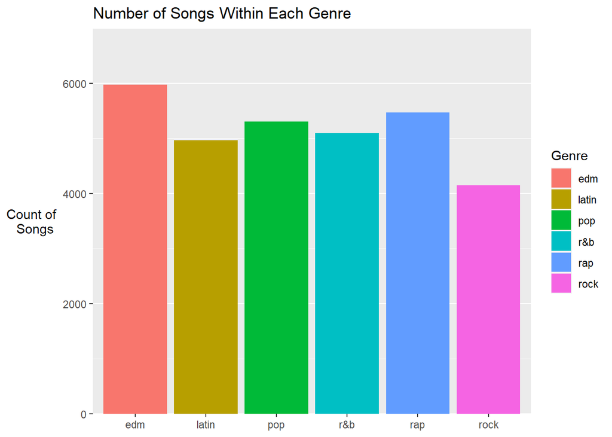

```r
songs %>% ggplot(aes(x = playlist_genre, fill = playlist_genre)) +
  geom_bar() +
  ggtitle("Number of Songs Within Each Genre") +
  scale_fill_discrete(name = "Genre") +
  scale_x_discrete(name = NULL) +
  scale_y_continuous(expand = c(0, 0), name = "Count of \n Songs") +
  theme(axis.title.y = element_text(angle = 0, vjust = .5)) +
  theme(panel.grid.major.x = element_blank()) +
  coord_cartesian(ylim = c(0, 7000))
```

As we can see, the makeup of songs in our dataset is pretty even, with EDM at the highest and rock at the lowest.

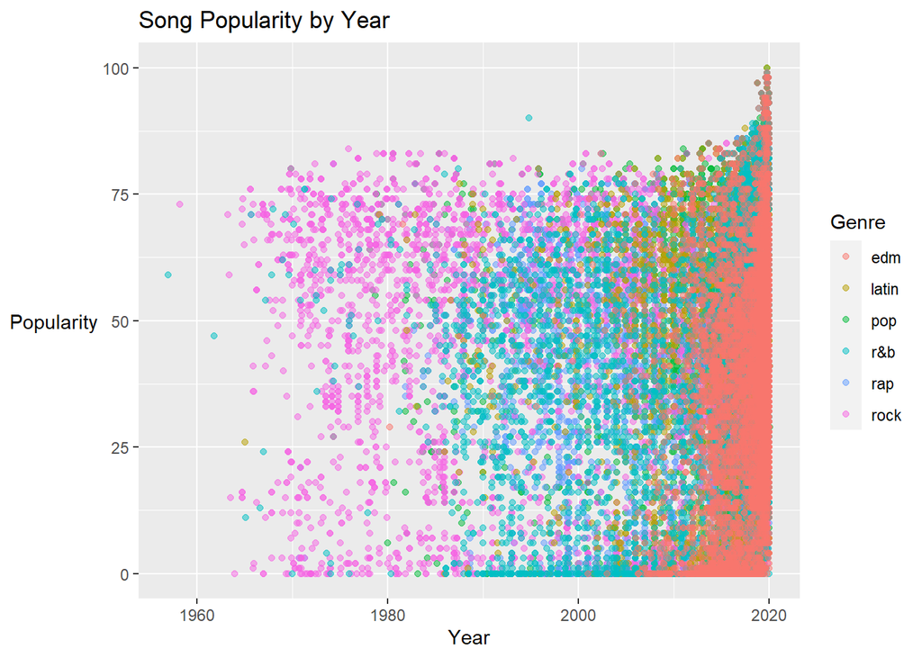

```r
songs %>% ggplot(aes(x = track_album_release_date, y = track_popularity, color = playlist_genre)) +
  geom_point(alpha = .5) +
  ggtitle("Song Popularity by Year") +
  scale_y_continuous(name = "Popularity") +
  labs(color = "Genre", x = "Year") +
  theme(axis.title.y = element_text(angle = 0, vjust = .5))
```

How do the genres rank in terms of popularity?

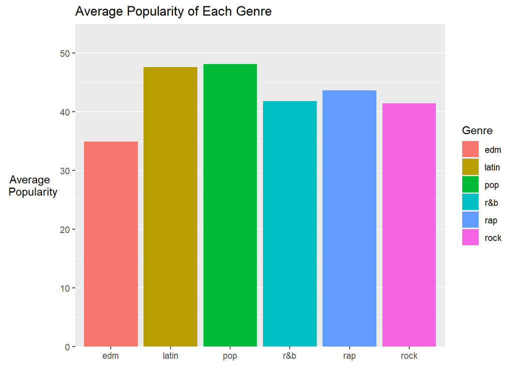

```r
popularity_means <- songs %>%
  group_by(playlist_genre) %>%
  dplyr::summarize(mean_popularity = mean(track_popularity))

popularity_means %>%
  ggplot(aes(x = playlist_genre,
             y = mean_popularity,
             fill = playlist_genre)) +
  geom_bar(stat = "identity") +
  ggtitle("Average Popularity of Each Genre") +
  scale_fill_discrete(name = "Genre") +
  scale_x_discrete(name = NULL) +
  scale_y_continuous(expand = c(0,0), name = "Average \n Popularity") +
  theme(axis.title.y = element_text(angle = 0, vjust = .5)) +
  theme(panel.grid.major.x = element_blank()) +
  coord_cartesian(ylim = c(0, 55))
```

Who are the most and least popular artists with at least five tracks in the dataset?

```r
# most popular
songs %>%
  group_by(track_artist) %>%
  filter(n() >= 5) %>%
  dplyr::summarize(mean_popularity = mean(track_popularity)) %>%
  arrange(desc(mean_popularity)) %>%
  slice_head(n = 10)
```

```
## # A tibble: 10 x 2
##    track_artist  mean_popularity
##    <chr>                   <dbl>
##  1 Trevor Daniel            97
##  2 Y2K                      91
##  3 Don Toliver              90.7
##  4 Roddy Ricch              88.2
##  5 DaBaby                   87.9
##  6 Kina                     85.4
##  7 JACKBOYS                 85.2
##  8 YNW Melly                84.6
##  9 Tainy                    84
## 10 Lewis Capaldi            83.7
```

```r
# least popular
songs %>%
  group_by(track_artist) %>%
  filter(n() >= 5) %>%
  dplyr::summarize(mean_popularity = mean(track_popularity)) %>%
  arrange(mean_popularity) %>%
  slice_head(n = 10)
```

```
## # A tibble: 10 x 2
##    track_artist         mean_popularity
##    <chr>                          <dbl>
##  1 Ballin Entertainment             0
##  2 CASIOPEA                         0
##  3 Hanybal                          0
##  4 Jamie Jones                      0
##  5 LemKuuja                         0
##  6 Lisa McClendon                   0
##  7 New World Sound                  0
##  8 T-SQUARE                         0
##  9 Green Tea                        0.5
## 10 Adventure Club                   0.6
```

How many cross-genre artists are there?

```r
songs %>%
  group_by(track_artist) %>%
  dplyr::summarize(n_unique = n_distinct(playlist_genre)) %>%
  filter(n_unique >= 2) %>%
  count()
```

```
## # A tibble: 1 x 1
##       n
##   <int>
## 1  1687
```

Which artists have tracks in the greatest variety of genres?

```r
songs %>%
  group_by(track_artist) %>%
  dplyr::summarize(n_unique = n_distinct(playlist_genre)) %>%
  filter(n_unique >= 2) %>%
  arrange(desc(n_unique)) %>%
  slice_head(n = 10)
```

```
## # A tibble: 10 x 2
##    track_artist   n_unique
##    <chr>             <int>
##  1 Billie Eilish         6
##  2 Coldplay              6
##  3 Eminem                6
##  4 Post Malone           6
##  5 Alan Walker           5
##  6 Anuel AA              5
##  7 Arizona Zervas        5
##  8 Avicii                5
##  9 Bad Bunny             5
## 10 blackbear             5
```

What dates are covered in the data set?

```r
min(songs$track_album_release_date)
```

```
## [1] "1957-01-01"
```

```r
max(songs$track_album_release_date)
```

```
## [1] "2020-01-29"
```

We will now compare genre characteristics in boxplots.

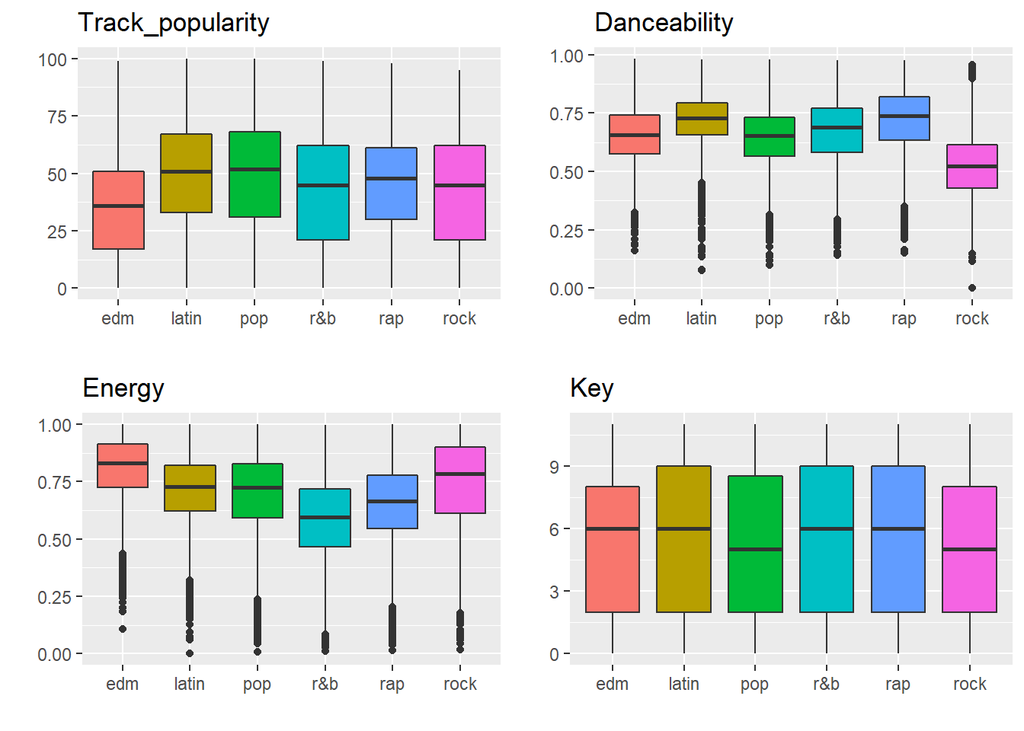

```r
myplots <-
  map(names(songs %>% select(where(is.numeric)) %>% select(-mode)),
      function(colName) {
        songs %>%
          ggplot(aes(x = playlist_genre,
                     y = !! sym(colName),
                     fill = playlist_genre)) +
          geom_boxplot() +
          theme(legend.position = "NONE") +
          labs(title = capitalize(colName), x = "", y = "")
    })
gridExtra::grid.arrange(grobs = myplots[c(1:4)])
```

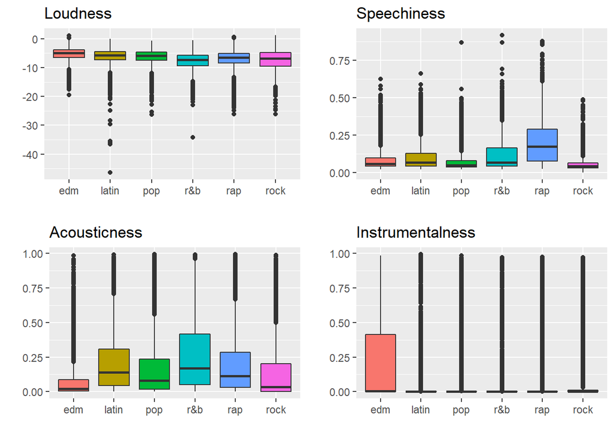

```r
gridExtra::grid.arrange(grobs = myplots[c(5:8)])
```

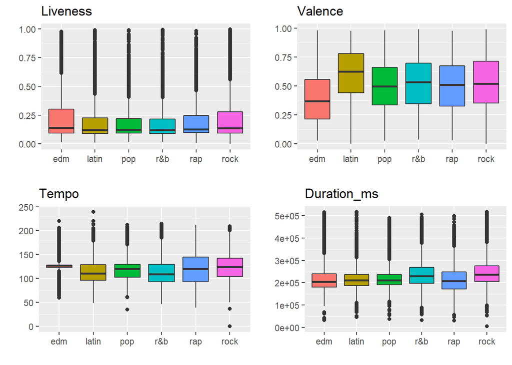

```r
gridExtra::grid.arrange(grobs = myplots[c(9:12)])
```

We will now compare the variables in pairs to determine if any influence the other, and whether they are significant to the overall model. New variable creation will not be necessary, and perhaps further grouping by the variable `liveness` or `instrumentalness` may be helpful as well.

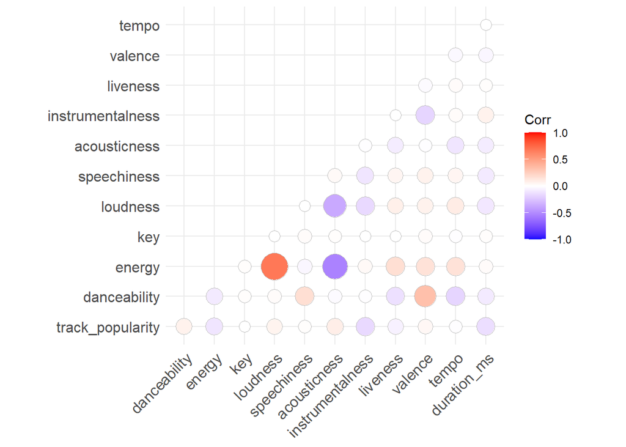

```r
corr_songs <-cor(songs %>% select(where(is.numeric)) %>% select(-mode))
ggcorrplot(corr_songs, method = "circle", type ="lower")
```

Next, we will generate our explanatory multiple linear regression model by using forward selection to determine which variables will be used as covariates.

```r
# forward selection base model
add1(lm(track_popularity ~ 1, data = songs),
     track_popularity ~ danceability + energy + key + loudness
     + speechiness + acousticness + instrumentalness + liveness
     + valence + tempo,
     test = "F")
```

```
## Single term additions
##
## Model:
## track_popularity ~ 1
##                  Df Sum of Sq      RSS    AIC  F value    Pr(>F)
## <none>                        19263406 199078
## danceability      1     91305 19172101 198933 147.3488 < 2.2e-16 ***
## energy            1    241413 19021993 198690 392.6670 < 2.2e-16 ***
## key               1         9 19263397 199080   0.0151   0.90208
## loudness          1     66309 19197097 198973 106.8705 < 2.2e-16 ***
## speechiness       1      2462 19260944 199076   3.9547   0.04675 *
## acousticness      1    143409 19119997 198849 232.0654 < 2.2e-16 ***
## instrumentalness  1    478515 18784891 198302 788.1471 < 2.2e-16 ***
## liveness          1     60115 19203292 198983  96.8556 < 2.2e-16 ***
## valence           1     32656 19230750 199028  52.5393 4.316e-13 ***
## tempo             1       585 19262821 199079   0.9401   0.33226
## ---
## Signif. codes:  0 '***' 0.001 '**' 0.01 '*' 0.05 '.' 0.1 ' ' 1
```

```r
# instrumentalness has the highest significant F value, so add it first
add1(lm(track_popularity ~ instrumentalness, data = songs),
     track_popularity ~ danceability + energy + key + loudness
     + speechiness + acousticness + instrumentalness + liveness
     + valence + tempo,
     test = "F")
```

```
## Single term additions
##
## Model:
## track_popularity ~ instrumentalness
##              Df Sum of Sq      RSS    AIC  F value    Pr(>F)
## <none>                    18784891 198302
## danceability  1     87069 18697822 198160 144.0712 < 2.2e-16 ***
## energy        1    219516 18565375 197940 365.8206 < 2.2e-16 ***
## key           1         0 18784891 198304   0.0002   0.98842
## loudness      1     22873 18762018 198266  37.7187 8.271e-10 ***
## speechiness   1       575 18784316 198303   0.9469   0.33051
## acousticness  1    140377 18644514 198072 232.9436 < 2.2e-16 ***
## liveness      1     61634 18723257 198202 101.8457 < 2.2e-16 ***
## valence       1      3297 18781594 198298   5.4309   0.01979 *
## tempo         1        91 18784800 198304   0.1501   0.69848
## ---
## Signif. codes:  0 '***' 0.001 '**' 0.01 '*' 0.05 '.' 0.1 ' ' 1
```

```r
# add energy
add1(lm(track_popularity ~ instrumentalness + energy, data = songs),
     track_popularity ~ danceability + energy + key + loudness
     + speechiness + acousticness + instrumentalness + liveness
     + valence + tempo,
     test = "F")
```

```
## Single term additions
##
## Model:
## track_popularity ~ instrumentalness + energy
##              Df Sum of Sq      RSS    AIC F value    Pr(>F)
## <none>                    18565375 197940
## danceability  1     65345 18500030 197833 109.278 < 2.2e-16 ***
## key           1        20 18565355 197942   0.034   0.85363
## loudness      1    444183 18121193 197193 758.346 < 2.2e-16 ***
## speechiness   1      1567 18563809 197939   2.611   0.10614
## acousticness  1     20758 18544617 197907  34.631 4.027e-09 ***
## liveness      1     29985 18535391 197892  50.049 1.532e-12 ***
## valence       1     17562 18547813 197913  29.294 6.264e-08 ***
## tempo         1      3627 18561748 197936   6.046   0.01394 *
## ---
## Signif. codes:  0 '***' 0.001 '**' 0.01 '*' 0.05 '.' 0.1 ' ' 1
```

```r
# add loudness
add1(lm(track_popularity ~ instrumentalness + energy + loudness,
        data = songs),
     track_popularity ~ danceability + energy + key + loudness
     + speechiness + acousticness + instrumentalness + liveness
     + valence + tempo,
     test = "F")
```

```
## Single term additions
##
## Model:
## track_popularity ~ instrumentalness + energy + loudness
##              Df Sum of Sq      RSS    AIC F value    Pr(>F)
## <none>                    18121193 197193
## danceability  1     33611 18087582 197137 57.4883 3.495e-14 ***
## key           1       104 18121088 197195  0.1778  0.673292
## speechiness   1      1924 18119268 197192  3.2856  0.069899 .
## acousticness  1     20338 18100854 197160 34.7612 3.766e-09 ***
## liveness      1     20015 18101178 197161 34.2080 5.002e-09 ***
## valence       1     39590 18081602 197127 67.7376 < 2.2e-16 ***
## tempo         1      3931 18117262 197188  6.7125  0.009578 **
## ---
## Signif. codes:  0 '***' 0.001 '**' 0.01 '*' 0.05 '.' 0.1 ' ' 1
```

```r
# add valence
add1(lm(track_popularity ~ instrumentalness + energy + loudness + valence,
        data = songs),
     track_popularity ~ danceability + energy + key + loudness
     + speechiness + acousticness + instrumentalness + liveness
     + valence + tempo,
     test = "F")
```

```
## Single term additions
##
## Model:
## track_popularity ~ instrumentalness + energy + loudness + valence
##              Df Sum of Sq      RSS    AIC F value    Pr(>F)
## <none>                    18081602 197127
## danceability  1   13886.0 18067716 197105 23.7760 1.088e-06 ***
## key           1      40.2 18081562 197129  0.0687  0.793245
## speechiness   1    3133.2 18078469 197124  5.3615  0.020593 *
## acousticness  1   15797.0 18065805 197102 27.0510 1.994e-07 ***
## liveness      1   17024.0 18064578 197100 29.1540 6.734e-08 ***
## tempo         1    5256.3 18076346 197120  8.9957  0.002708 **
## ---
## Signif. codes:  0 '***' 0.001 '**' 0.01 '*' 0.05 '.' 0.1 ' ' 1
```

```r
# add liveness
add1(lm(track_popularity ~ instrumentalness + energy + loudness + valence
        + liveness,
        data = songs),
     track_popularity ~ danceability + energy + key + loudness
     + speechiness + acousticness + instrumentalness + liveness
     + valence + tempo,
     test = "F")
```

```
## Single term additions
##
## Model:
## track_popularity ~ instrumentalness + energy + loudness + valence +
##     liveness
##              Df Sum of Sq      RSS    AIC F value    Pr(>F)
## <none>                    18064578 197100
## danceability  1   11209.3 18053369 197083 19.2075 1.176e-05 ***
## key           1      43.4 18064535 197102  0.0743  0.785142
## speechiness   1    2285.7 18062293 197098  3.9146  0.047876 *
## acousticness  1   16296.6 18048282 197074 27.9327 1.265e-07 ***
## tempo         1    5176.8 18059401 197093  8.8677  0.002905 **
## ---
## Signif. codes:  0 '***' 0.001 '**' 0.01 '*' 0.05 '.' 0.1 ' ' 1
```

```r
# add acousticness
add1(lm(track_popularity ~ instrumentalness + energy + loudness + valence
        + liveness + acousticness,
        data = songs),
     track_popularity ~ danceability + energy + key + loudness
     + speechiness + acousticness + instrumentalness + liveness
     + valence + tempo,
     test = "F")
```

```
## Single term additions
##
## Model:
## track_popularity ~ instrumentalness + energy + loudness + valence +
##     liveness + acousticness
##              Df Sum of Sq      RSS    AIC F value    Pr(>F)
## <none>                    18048282 197074
## danceability  1   15160.5 18033121 197050 26.0064 3.423e-07 ***
## key           1      25.7 18048256 197076  0.0441  0.833688
## speechiness   1    2400.0 18045882 197072  4.1140  0.042538 *
## tempo         1    5821.7 18042460 197066  9.9813  0.001583 **
## ---
## Signif. codes:  0 '***' 0.001 '**' 0.01 '*' 0.05 '.' 0.1 ' ' 1
```

```r
# add danceability
add1(lm(track_popularity ~ instrumentalness + energy + loudness + valence
        + liveness + acousticness + danceability,
        data = songs),
     track_popularity ~ danceability + energy + key + loudness
     + speechiness + acousticness + instrumentalness + liveness
     + valence + tempo,
     test = "F")
```

```
## Single term additions
##
## Model:
## track_popularity ~ instrumentalness + energy + loudness + valence +
##     liveness + acousticness + danceability
##             Df Sum of Sq      RSS    AIC F value    Pr(>F)
## <none>                   18033121 197050
## key          1      14.0 18033107 197052  0.0240  0.876940
## speechiness  1    5049.4 18028072 197043  8.6639  0.003248 **
## tempo        1    9682.7 18023438 197035 16.6181 4.583e-05 ***
## ---
## Signif. codes:  0 '***' 0.001 '**' 0.01 '*' 0.05 '.' 0.1 ' ' 1
```

```r
# add tempo
add1(lm(track_popularity ~ instrumentalness + energy + loudness + valence
        + liveness + acousticness + danceability + tempo,
        data = songs),
     track_popularity ~ danceability + energy + key + loudness
     + speechiness + acousticness + instrumentalness + liveness
     + valence + tempo,
     test = "F")
```

```
## Single term additions
##
## Model:
## track_popularity ~ instrumentalness + energy + loudness + valence +
##     liveness + acousticness + danceability + tempo
##             Df Sum of Sq      RSS    AIC F value    Pr(>F)
## <none>                   18023438 197035
## key          1      24.9 18023414 197037  0.0427 0.8362915
## speechiness  1    6498.3 18016940 197026 11.1565 0.0008383 ***
## ---
## Signif. codes:  0 '***' 0.001 '**' 0.01 '*' 0.05 '.' 0.1 ' ' 1
```

```r
# add speechiness
add1(lm(track_popularity ~ instrumentalness + energy + loudness + valence
        + liveness + acousticness + danceability + tempo + speechiness,
        data = songs),
     track_popularity ~ danceability + energy + key + loudness
     + speechiness + acousticness + instrumentalness + liveness
     + valence + tempo,
     test = "F")
```

```
## Single term additions
##
## Model:
## track_popularity ~ instrumentalness + energy + loudness + valence +
##     liveness + acousticness + danceability + tempo + speechiness
##        Df Sum of Sq      RSS    AIC F value Pr(>F)
## <none>              18016940 197026
## key     1    44.557 18016896 197028  0.0765 0.7821
```

```r
# key is not found to be significant
```

Based on our forward selection process, our model will use `instrumentalness`, `energy`, `loudness`, `valence`, `liveness`, `acousticness`, `danceability`, `tempo`, and `speechiness` as covariates for the response variable `track_popularity`. `key` was not found to be significant, so it will not be included in the model.

```r
model1 <- lm(track_popularity ~ instrumentalness + energy + loudness + valence
             + liveness + acousticness + danceability + tempo + speechiness,
             data = songs)
summary(model1)
```

```
##
## Call:
## lm(formula = track_popularity ~ instrumentalness + energy + loudness +
##     valence + liveness + acousticness + danceability + tempo +
##     speechiness, data = songs)
##
## Residuals:
##     Min      1Q  Median      3Q     Max
## -62.369 -17.262   3.129  18.874  78.202
##
## Coefficients:
##                    Estimate Std. Error t value Pr(>|t|)
## (Intercept)       69.600763   1.637877  42.494  < 2e-16 ***
## instrumentalness -12.463786   0.644196 -19.348  < 2e-16 ***
## energy           -31.884870   1.240935 -25.694  < 2e-16 ***
## loudness           1.784146   0.066932  26.656  < 2e-16 ***
## valence            3.198616   0.662528   4.828 1.39e-06 ***
## liveness          -4.208941   0.913680  -4.607 4.11e-06 ***
## acousticness       4.687185   0.752145   6.232 4.67e-10 ***
## danceability       6.755458   1.083990   6.232 4.66e-10 ***
## tempo              0.023060   0.005275   4.372 1.24e-05 ***
## speechiness       -4.636935   1.388245  -3.340 0.000838 ***
## ---
## Signif. codes:  0 '***' 0.001 '**' 0.01 '*' 0.05 '.' 0.1 ' ' 1
##
## Residual standard error: 24.13 on 30932 degrees of freedom
## Multiple R-squared:  0.06471,    Adjusted R-squared:  0.06443
## F-statistic: 237.8 on 9 and 30932 DF,  p-value: < 2.2e-16
```

Our model only accounts for about 6% of the variation in `track_popularity`. Let’s take a look at the QQ plot and histogram of our residuals to see if any improvements can be made.

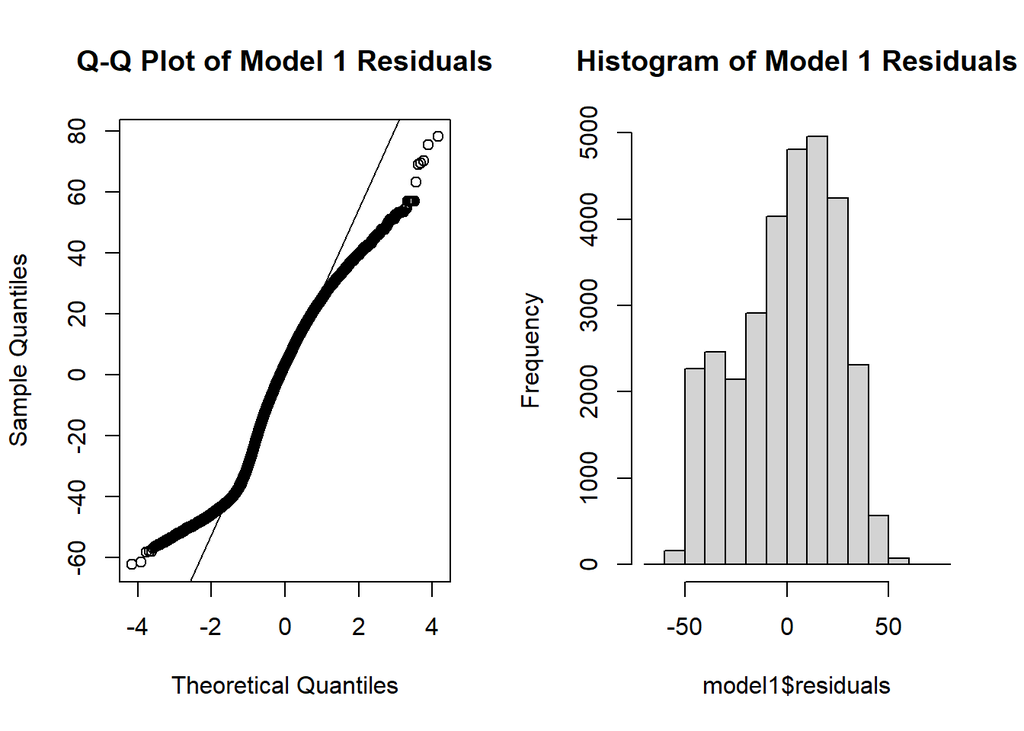

```r
par(mfrow = c(1,2))
qqnorm(model1$residuals, main = "Q-Q Plot of Model 1 Residuals")
qqline(model1$residuals)
hist(model1$residuals, main = "Histogram of Model 1 Residuals")
```

```r
par(mfrow = c(1,1))
```

The QQ plot of the residuals shows a pattern that indicates non-normality in our residuals, and the histogram reveals light tails. These results suggest that transforming our response variable might be in order, so let’s try that. We’ll create five alternative models using the following transformations on `track_popularity`:

- square root transformation
- log transformation
- reciprocal square root transformation
- reciprocal transformation
- arcsin transformation

```r
# square root transformation
songs$sqrt_track_popularity <- sqrt(songs$track_popularity)
model2 <- lm(sqrt_track_popularity ~ instrumentalness + energy + loudness +
               valence + liveness + acousticness + danceability + tempo +
               speechiness,
             data = songs)

# log transformation
songs$log_track_popularity <- log(songs$track_popularity)
model3 <- lm(log_track_popularity ~ instrumentalness + energy + loudness +
               valence + liveness + acousticness + danceability + tempo +
               speechiness,
             data = songs[songs$log_track_popularity > -Inf,])

# reciprocal square root transformation
songs$recip_sqrt_track_popularity <- songs$track_popularity ^ (-.5)
model4 <- lm(recip_sqrt_track_popularity ~ instrumentalness + energy + loudness +
               valence + liveness + acousticness + danceability + tempo +
               speechiness,
             data = songs[songs$log_track_popularity > -Inf,])

# reciprocal transformation
songs$recip_track_popularity <- songs$track_popularity ^ (-1)
model5 <- lm(recip_track_popularity ~ instrumentalness + energy + loudness +
               valence + liveness + acousticness + danceability + tempo +
               speechiness,
             data = songs[songs$recip_sqrt_track_popularity < Inf,])

# arcsin transformation
songs$asin_track_popularity <- asin(songs$sqrt_track_popularity)
model6 <- lm(asin_track_popularity ~ instrumentalness + energy + loudness +
               valence + liveness + acousticness + danceability + tempo +
               speechiness,
             data = songs[!(is.nan(songs$asin_track_popularity)),])
```

Unfortunately, none of our transformations had a beneficial effect on our residuals, as can be seen in the QQ plots of our alternate models.

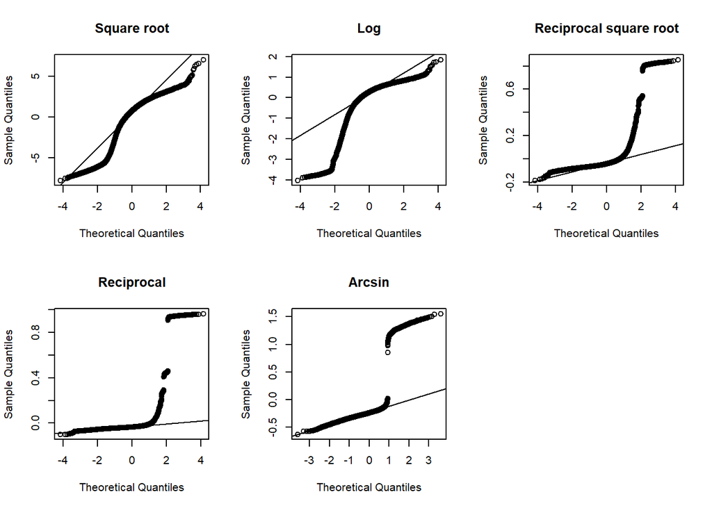

```r
par(mfrow = c(2, 3))

qqnorm(model2$residuals, main = "Square root")
qqline(model2$residuals)

qqnorm(model3$residuals, main = "Log")
qqline(model3$residuals)

qqnorm(model4$residuals, main = "Reciprocal square root")
qqline(model4$residuals)

qqnorm(model5$residuals, main = "Reciprocal")
qqline(model5$residuals)

qqnorm(model6$residuals, main = "Arcsin")
qqline(model6$residuals)

par(mfrow = c(1,1))
```

We can also tell by looking at our models’ adjusted R-squared values that our original model performs better than any of our alternative models.

```r
(df <- data.frame(Model = c(1:6),
                 Transformation = c("None",
                                    "Square root",
                                    "Log",
                                    "Reciprocal square root",
                                    "Reciprocal",
                                    "Arcsin"),
                 AdjRsqr = c(summary(model1)$adj.r.squared,
                             summary(model2)$adj.r.squared,
                             summary(model3)$adj.r.squared,
                             summary(model4)$adj.r.squared,
                             summary(model5)$adj.r.squared,
                             summary(model6)$adj.r.squared)))
```

```
##   Model         Transformation     AdjRsqr
## 1     1                   None 0.064434292
## 2     2            Square root 0.050388224
## 3     3                    Log 0.024922753
## 4     4 Reciprocal square root 0.009597271
## 5     5             Reciprocal 0.003216709
## 6     6                 Arcsin 0.020659481
```

### Section 6: Summary